# Unit 7: Stats wrap-up

## Unit 7: Agenda

- chisquared test for independence
- Fisher's exact test, KS GoF test
- QQ plots
- paired and unpaired t-tests
- Power and effect size
- ANOVA
- Mann Whitney U test (wilcox test)
- Exercises for Unit 7

## Simulated vs real data

- Simulated data is useful to do a quick test to check that you understand the theory and how to run the functions in R
- So usually when I am trying to explain a statistical concept such as the chisquared test, I will generate simulated data to explain the concept
- Examples of *simulated* data:

```r
x <- sample(1:6,100,replace=TRUE) # sample data from uniform discrete
y <- rt(100,3) # sample data from a t-distribution
```

- The real purpose of all these statistical tools is to run them on *REAL* data, we will eventually get to some real data examples

## Behavior of `chisquared.test(x,p)`

1. if `x` is a one-way contingency-table then it will do a goodness of fit test
   - if `p` is omitted then since expected frequencies are not supplied it will assume a uniform discrete with `p = 1/length(x)`
2. If `x` is a two-way contingency table it will do a test for independence that is it will test the null hypothesis that the joint distribution is a product of the row and column marginals
3. In all cases the expected (null-hypothesis) cell counts *should* be at least 5 in each cell
4. Careful about passing a table with margins added, it treats the margins as a bin

```r
a <- table(sample(1:4,size=30,replace=T))
```

```
##
## 1 2 3 4
## 6 7 8 9
```

```r
chisq.test(a)
```

```
##
##  Chi-squared test for given probabilities
##
## data:  a
## X-squared = 0.66667, df = 3, p-value = 0.881
```

In this case the expected counts \([E_1,E_2,E_3,E_4]\) are

\(30p = 30[0.25,0.25,0.25,0.25] = [7.5,7.5,7.5,7.5]\)

## Chisquared test for independence

A two-way table is another name for a contingency table. Let's examine the Kobe two-way table again:

```
##       quarter
## basket   1 1OT   2   3   4 Sum
##    H    18   3  11  16  10  58
##    M    18   4  14  18  21  75
##    Sum  36   7  25  34  31 133
```

Our null and alternative hypotheses are:

\[H_0: \textrm{shots are H or a M independent of the quarter}\] \[H_A: \textrm{whether H or a M depends on which quarter}\] We want to see if our **sample data** is consistent with \(H_0\)

Let's look at the cell proportions of the data

```
##       quarter
## basket     1   1OT     2     3     4   Sum
##    H   0.135 0.023 0.083 0.120 0.075 0.436
##    M   0.135 0.030 0.105 0.135 0.158 0.563
##    Sum 0.270 0.053 0.188 0.255 0.233 0.999
```

Marginal for baskets, \(P(\textrm{baskets}): {0.436, 0.563}\)

for quarters, \(P(\textrm{quarters}): {0.270, 0.053, 0.188, 0.255, 0.233}\)

So, if the probability of shots hit or miss is independent of the quarter then we can state the null hypothesis as

\[H_0: P(basket=X \textrm{ AND } quarter = Y) = P(X)P(Y)\]

where \(P(X)\), \(P(Y)\) are the marginal probabilities for baskets and quarters

The expected counts under the null hypothesis can get by multiplying the marginal products times the number of observations (\(n=133\))

```r
    P_A <- c(0.437,0.563)
    P_B <- c(0.270, 0.053, 0.188, 0.255, 0.233)
    expected_counts <- round((P_A %o% P_B) *133,1)
```

```
##
##  15.7 3.1 10.9 14.8 13.5
##  20.2 4.0 14.1 19.1 17.4
```

Let's check this manually and then see that `chisq.test` produces the same result

```r
X_squared = sum((kobes_real_data - expected_counts)^2/expected_counts)
round(X_squared,2)
```

```
## [1] 2.39
```

```r
chisq.test(kobes_real_data)
```

```
##
##  Pearson's Chi-squared test
##
## data:  kobes_real_data
## X-squared = 2.3898, df = 4, p-value = 0.6645
```

Graphical plot of the solution

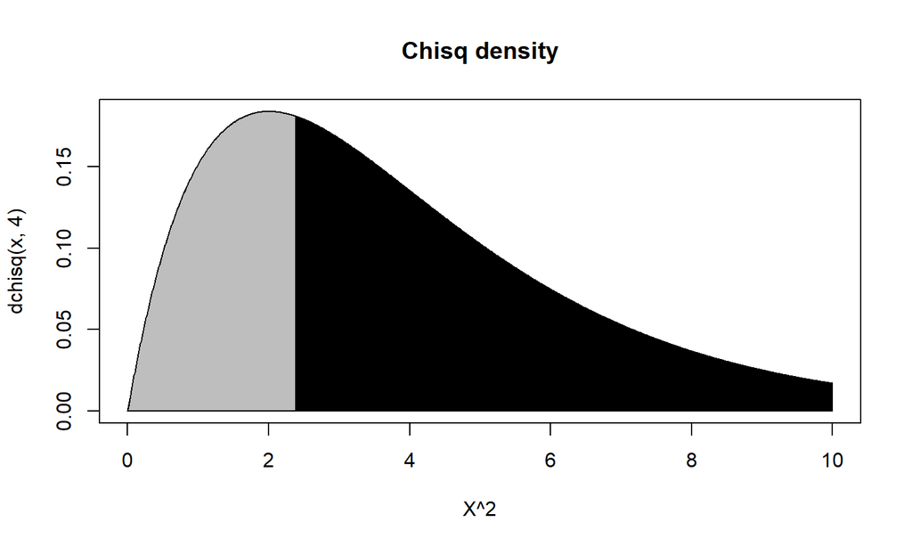

From \(p\)-value = 0.66 we can reasonably conclude that kobe's hits and misses were independent of the quarter in the sample data.

## Fisher exact test

Let's say there is a class with 12 women and 12 men and you want to test the hypothesis that the proportion of studying individuals is higher among women than men.

|  | **Men** | **Women** | *Row Total* |
| --- | --- | --- | --- |
| **Studying** | **1** | **9** | 10 |
| **Not-studying** | **11** | **3** | 14 |
| *Column Total* | 12 | 12 | 24 |

Assuming the null hypothesis, that men and women are equally likely to study, what is the probability (*p* value) that these 10 studiers would be so unevenly distributed between?

In order to proceed with Fisher test, we introduce notations

|  | **Men** | **Women** | *Row Total* |
| --- | --- | --- | --- |
| **Studying** | **a** | **b** | a+b |
| **Not-studying** | **c** | **d** | c+d |
| *Column Total* | a+c | b+d | a+b+c+d(=N) |

Fisher showed that the probability is **hypergeometric**

\(p = \frac{\binom{a+b}{a}\binom{c+d}{c}}{\binom{N}{a+c}} \qquad \to \qquad p(X;N,K,n)= \frac{\binom{K}{X}\binom{N-K}{n-X}}{\binom{N}{n}}\)

where \(N\) is the population size (24 students),

\(K\) is the number of success states (10 studiers)

\(n\) is the number of draws e.g. (draw 12 men)

\(X\) is the number of successes, (1 man studies)

Remember, p-values refer to the data **OR any more extreme cases against \(H_0\)** so we should also consider this case as well

|  | **Men** | **Women** | *Row Total* |
| --- | --- | --- | --- |
| **Studying** | **0** | **10** | 10 |
| **Not-studying** | **12** | **2** | 14 |
| *Column Total* | 12 | 12 | 24 |

\[p/2 = \frac{{\binom{10}{1}} {\binom{14}{11}}} {\binom{24}{12}} + \frac{{\binom{10}{0}} {\binom{14}{12}}} {\binom{24}{12}} \to p \approx 0.00276\] we multiplied by 2, to do a two-tailed test, however, the hypergeometric is not exactly symmetric so this is just an approximation

Note that the more extreme tail values are calculated with the same marginals. let's apply fisher test and see if results agree

```r
men_studiers <- data.frame(Men=c(1,11),Women=c(9,3))
 fisher.test(men_studiers)
```

```
##
##  Fisher's Exact Test for Count Data
##
## data:  men_studiers
## p-value = 0.002759
## alternative hypothesis: true odds ratio is not equal to 1
## 95 percent confidence interval:
##  0.0006438284 0.4258840381
## sample estimates:
## odds ratio
## 0.03723312
```

## Kolmogorov-Smirnov goodness of fit

This is another goodness of fit test. It compares the empirical cumulative distribution of a sample versus a theoretical CDF OR versus another sample's empirical CDF.

How it works: demonstrate on chalkboard

```r
x <- rnorm(50)
y <- runif(30)
# Do x and y come from the same distribution?
ks.test(x, y)
```

```
##
##  Two-sample Kolmogorov-Smirnov test
##
## data:  x and y
## D = 0.50667, p-value = 6.866e-05
## alternative hypothesis: two-sided
```

for this example, the null hypothesis, \(H_0\), states that the two samples \(x\) and \(y\), come from the same distribution (NOT true)

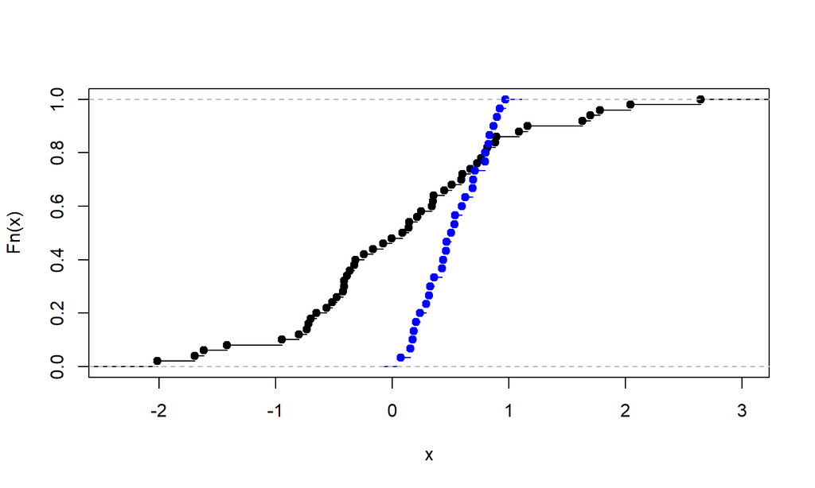

```r
plot.ecdf(x,main=NULL)
plot.ecdf(y,add=T,col='blue')
```

## quantile-quantile (QQ) plots

QQ plots are a way to visually inspect your data to perform inference

- Procedure is to order your data and plot vs normal \(k/n\) quantiles or some other distribution/sample on horizontal
- The idea is that if a random sample comes from a distribution then \(n\) quantiles of \(n\) observed data match should closely follow the \(n\) quantiles of the distribution
- If your sample quantiles plotted against theoretical quantiles **form a straight line**, then it is likely your data belongs to the theoretical distribution (default is normal)
- some of the **far-tail effects** are due to limited sample size

## Normal QQ plot

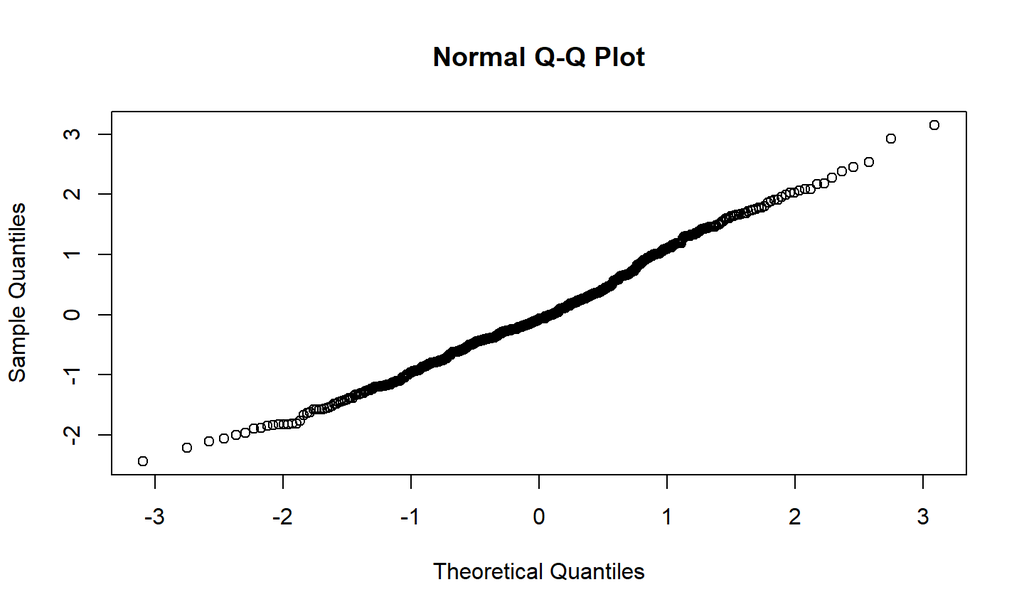

```r
qqnorm(rnorm(500)) # it's a match! Ignore, the far-tail variance
```

Since the sample data's QQ plot below is not straight line, it is not a match to the normal distribution

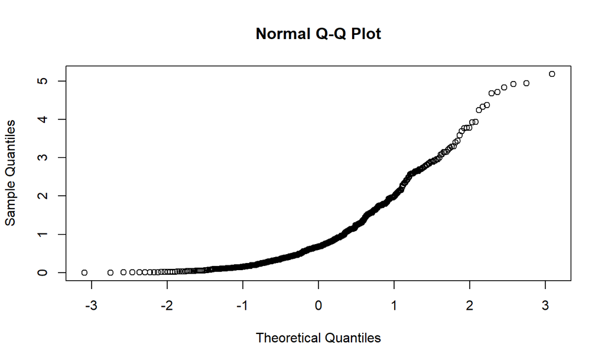

```r
qqnorm(rexp(500,rate=1)) # oops
```

You can do a QQ plot with some other type of distribution on the horizontal axis (theoretical quantiles)

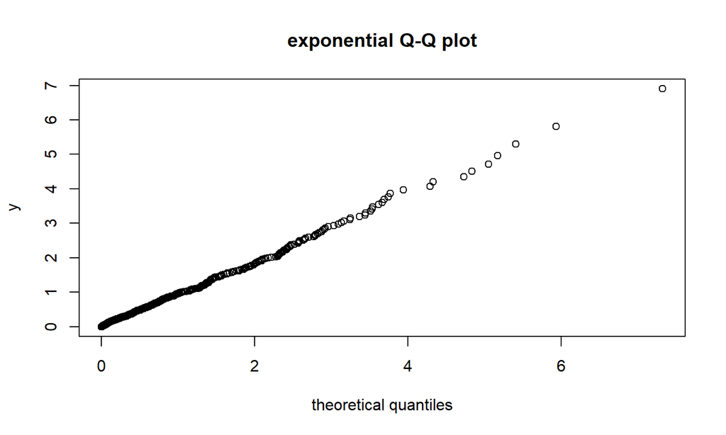

```r
x <- rexp(500,rate=1);   y <- qexp(ppoints(length(x)))
qqplot(x,y,main="exponential Q-Q plot",xlab="theoretical quantiles")
```

Here is an example of a **heavy tailed** sample

```r
y <- rt(600, df = 3)  # t-distribution has fat tails
```

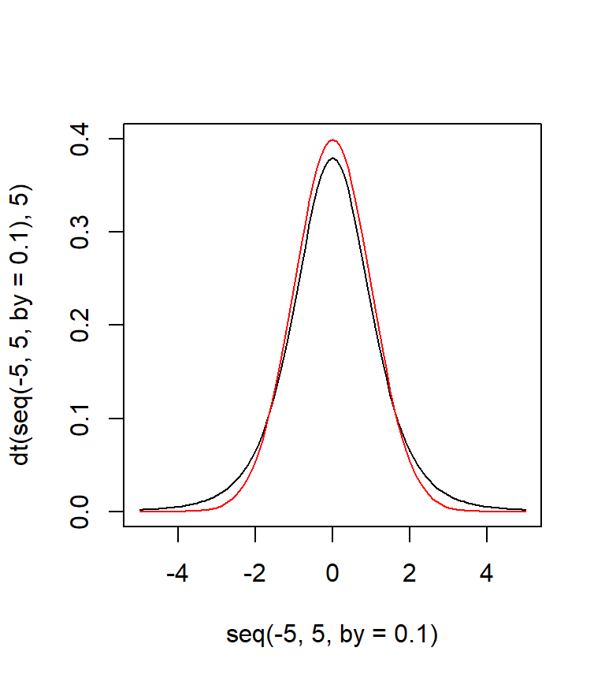

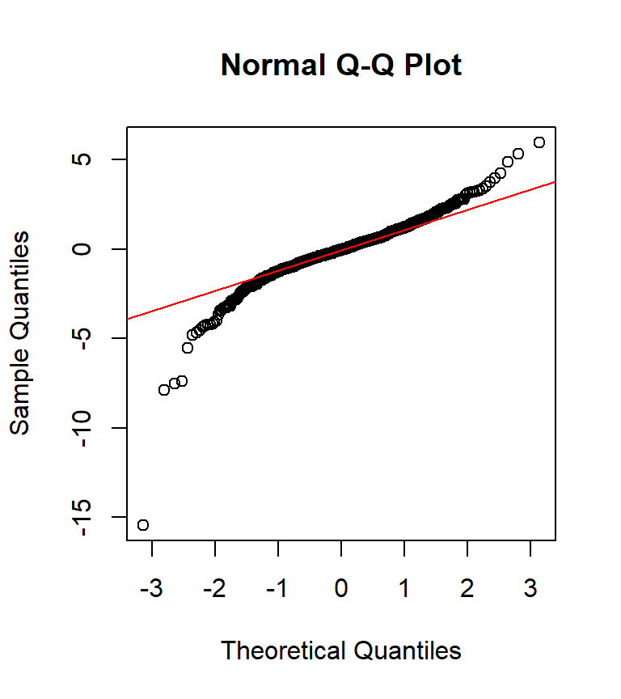

Here is an example of a **light** tailed sample

```r
y <- runif(200); y <- y-mean(y)  # uniform - symmetrized
```

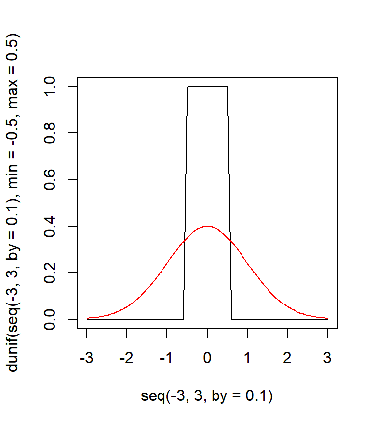

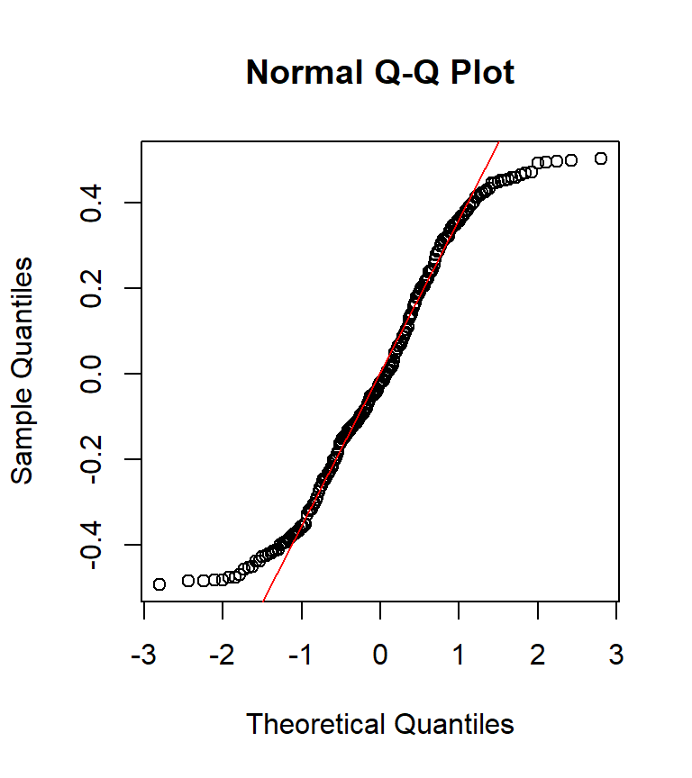

Here is an example of a **right-skew**, appears *left-leaning*, but the right tail is longer (heavier), while the left-tail is short (lighter)

```r
y <- rchisq(2000,4); y <- y - mean(y) # symmetrize
```

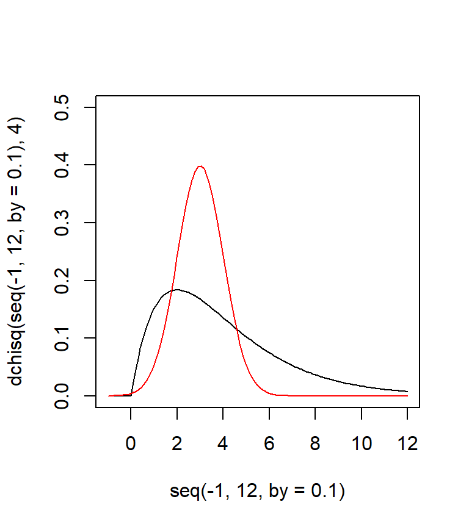

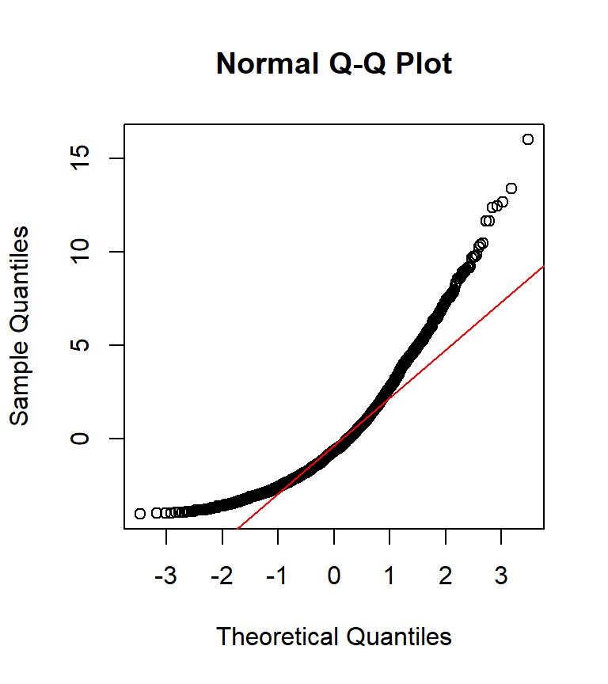

Here is an example of a **left-skew**, appears *right-leaning*, but the **left** tail is longer (heavier), while the right-tail is short (lighter)

```r
y <- rbeta(2000,8,2) # sample the beta distribution
```

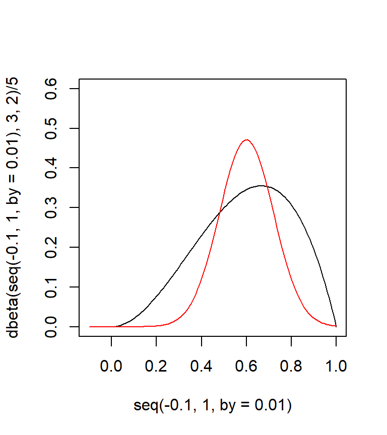

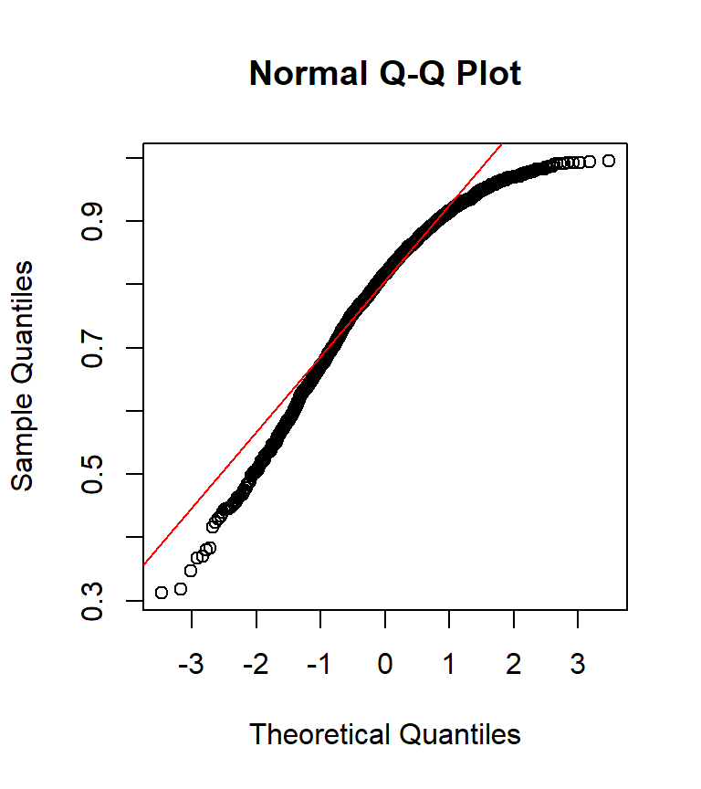

You can also use a QQ plot with sample data quantiles on each axis to test if they belong to the same distribution.

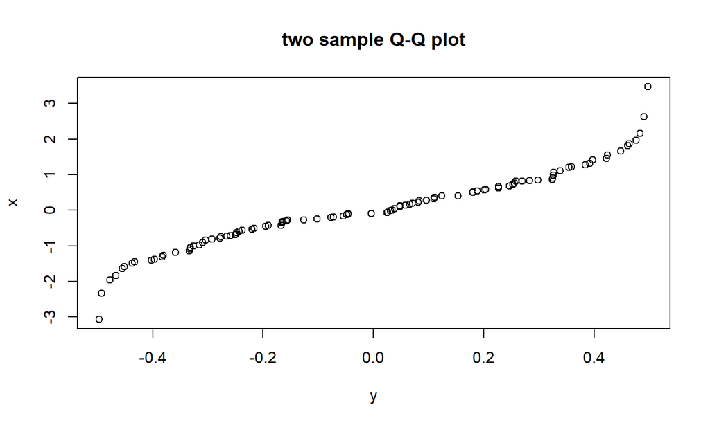

```r
x <- rnorm(300);  y <- runif(100,min=-0.5,max=0.5)
qqplot(y,x,main="two sample Q-Q plot") # should be heavy tailed
```

## Testing for differences in means

- Depends on whether your data is **paired** or **unpaired**
- For *paired data*, there is a **one-to-one** correspondence between data points in each sample (column). The hypothesis testing is conducted in the same way as for a single mean test, but replacing \(\overline{X}\) with the average of difference column

| name | before_weight | after_weight | difference |
| --- | --- | --- | --- |
| Cindy | 145 | 141 | 4 |
| July | 136 | 131 | 5 |
| Tom | 179 | 177 | 2 |
| Joe | 162 | 165 | -3 |
| Ann | 151 | 143 | 8 |
| Mike | 188 | 184 | 4 |

Note that the null hypothesis, \(H_0\) is that the true (population) difference in means is zero, or in other words:

\(H_0\): *The diet has no affect on the individuals' weight*

To run the paired t-test

```r
t.test(dieters$before_weight,dieters$after_weight,paired = TRUE)
```

```
##
##  Paired t-test
##
## data:  dieters$before_weight and dieters$after_weight
## t = 2.225, df = 5, p-value = 0.07665
## alternative hypothesis: true difference in means is not equal to 0
## 95 percent confidence interval:
##  -0.5177761  7.1844428
## sample estimates:
## mean of the differences
##                3.333333
```

## Unpaired data

the MASS library dataframe `birthwt` contains 189 observations of baby birth weights and associated risk factors shown below

| mother.age | mother.weight | race | mother.smokes | birthwt.grams |
| --- | --- | --- | --- | --- |
| 19 | 182 | black | no | 2523 |
| 33 | 155 | other | no | 2551 |
| 20 | 105 | white | yes | 2557 |
| 21 | 108 | white | yes | 2594 |
| 18 | 107 | white | yes | 2600 |
| 21 | 124 | other | no | 2622 |

We want to test to see if there is a difference between the average birthweights between mothers who smoke and mothers who don't smoke

```r
ddply(birthwt, ~ mother.smokes, summarize, # this splits the data...
      group.size = length(birthwt.grams),  # ...  by smoking status...
      mean.birthwt = mean(birthwt.grams),  # ... and then applies...
      sd.birthwt = sd(birthwt.grams),      # ... functions to each...
      se.mean.birthwt = sd.birthwt / sqrt(group.size) #...  group
      )
```

| mother.smokes | group.size | mean.birthwt | sd.birthwt | se.mean.birthwt |
| --- | --- | --- | --- | --- |
| no | 115 | 3055.7 | 752.7 | 70.2 |
| yes | 74 | 2771.9 | 659.6 | 76.7 |

Notice that the data is *unpaired* since smokers, and non-smokers are **different** groups of mothers. **A paired t-test would check the difference of two variable means for *the same mother***.

Next, we setup our hypothesis testing framework -

\(H_0\): There is no difference in average birth weight for newborns from mothers who did and did not smoke, or \(\mu_n -\mu_s = 0\), where \(\mu_n\) represents non-smoking mothers and \(\mu_s\) represents mothers who smoked.

\(H_A\): There is some difference in average newborn weights from mothers who did and did not smoke (\(\mu_n -\mu_s \neq 0\)).

We check the two conditions necessary to model the difference in sample means using the t-distribution.

1. It is reasonable to assume that observations are **independent**, both within and between samples.
2. With both data sets over \(n= 30\) observations, it is reasonable to assume **normality** (of the sample means about true means) as long as there are no extreme outliers

```r
non_smokers <-   filter(birthwt,mother.smokes == 'no')
smokers <-   filter(birthwt,mother.smokes == 'yes')
```

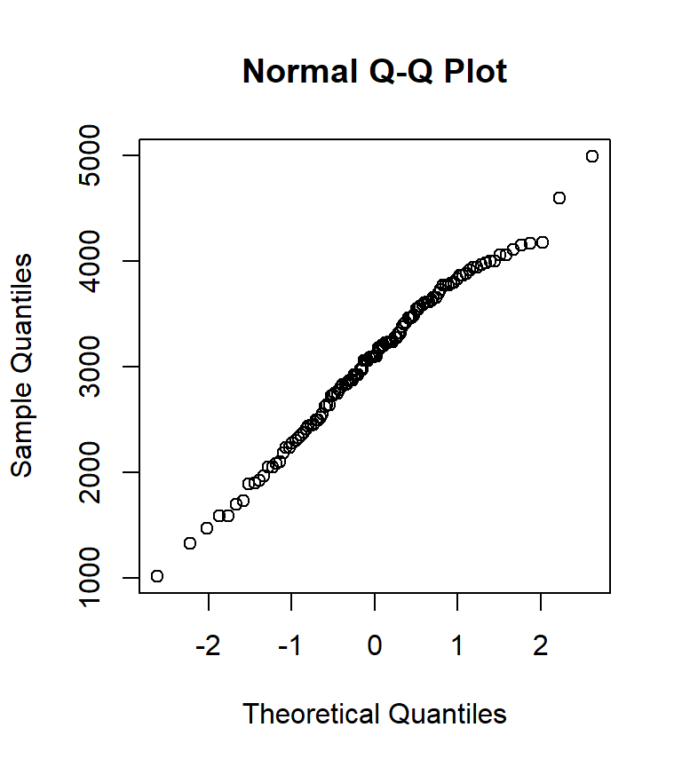

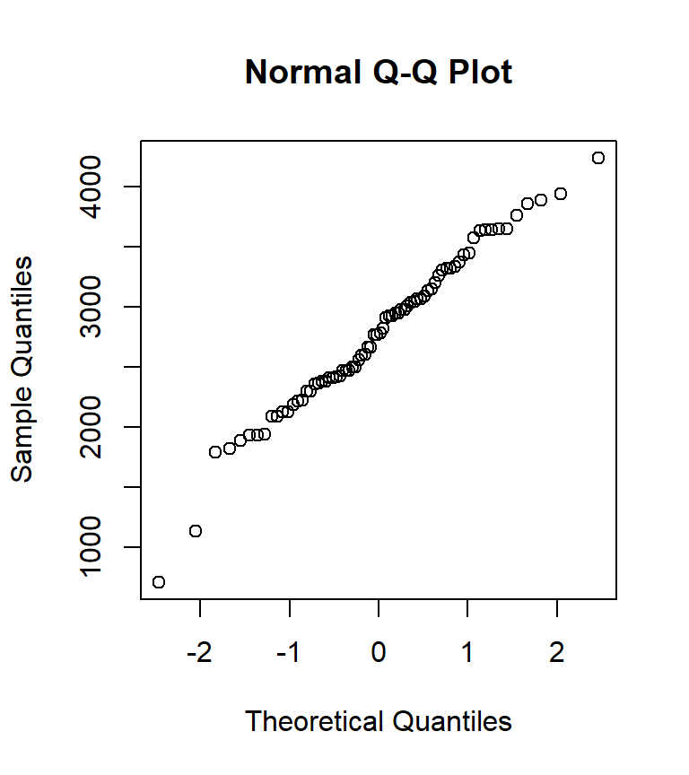

Thus normality condition is reasonable no extreme outliers

For a single mean \(t\)-test, the null hypothesis, \(H_0\), is that the population mean \(\mu=\mu_0\) and the null distribution of \(\hat{\mu} = \overline{X}\) is:

\(\frac{\overline{X} -\mu_0}{SE} \sim t(n-1)\) where \(SE = \frac{S}{\sqrt{n}}\)

from \(n\) observations. We then calculate a \(p\) value from the T-score by finding the tail areas of the t-distribution.

For two-sample unpaired t-test with unequal variances, the "Welch" t-test of \(H_0\), says \((\overline{X_1} - \overline{X_2})/SE\) is \(t\)-distributed with

\(SE = \sqrt{\frac{S^2_1}{n_1}+ \frac{S^2_2}{n_2}}\)

and the smaller of \(n_1 -1\) or \(n_2 -1\) is the degrees of freedom. The rest of the procedure to find the \(p\) value or confidence interval is identical to previous cases.

```r
birthwt.t.test <- t.test(birthwt.grams ~ mother.smokes,data=birthwt)
birthwt.t.test
```

```
##
##  Welch Two Sample t-test
##
## data:  birthwt.grams by mother.smokes
## t = 2.7299, df = 170.1, p-value = 0.007003
## alternative hypothesis: true difference in means is not equal to 0
## 95 percent confidence interval:
##   78.57486 488.97860
## sample estimates:
##  mean in group no mean in group yes
##          3055.696          2771.919
```

note that the result of the t-test is a dataframe

`birthwt.t.test$p.value =` 0.0070025

This is **significant** at level \(\alpha = 0.01\)

another way to run the t-test

```r
with(birthwt, t.test(x=birthwt.grams[mother.smokes=="no"],
                     y=birthwt.grams[mother.smokes=="yes"]))
```

```
##
##  Welch Two Sample t-test
##
## data:  birthwt.grams[mother.smokes == "no"] and birthwt.grams[mother.smokes == "yes"]
## t = 2.7299, df = 170.1, p-value = 0.007003
## alternative hypothesis: true difference in means is not equal to 0
## 95 percent confidence interval:
##   78.57486 488.97860
## sample estimates:
## mean of x mean of y
##  3055.696  2771.919
```

`with(df, )` specifies the dataframe from which the function gets data, e.g. it is an alternative to `t.test(x,y,data=df)`. In R, there are many ways to do the same thing!

## 2X2 table tests

We can look at things from the contingency table perspective

```r
birthwt_table <- with(birthwt, table(birthwt.below.2500, mother.smokes))
birthwt_table
```

```
##                   mother.smokes
## birthwt.below.2500 no yes
##                no  86  44
##                yes 29  30
```

```r
chisq.test(birthwt_table)
```

```
##
##  Pearson's Chi-squared test with Yates' continuity correction
##
## data:  birthwt_table
## X-squared = 4.2359, df = 1, p-value = 0.03958
```

We can also run fishers test on the birthwt data giving similar results to the chisq test

```r
fisher.test(birthwt_table) #test for INDEPENDENCE
```

```
##
##  Fisher's Exact Test for Count Data
##
## data:  birthwt_table
## p-value = 0.03618
## alternative hypothesis: true odds ratio is not equal to 1
## 95 percent confidence interval:
##  1.028780 3.964904
## sample estimates:
## odds ratio
##   2.014137
```

**Interpretation** The odds of low birth weight are 2.01 times greater when the mother smokes than when the mother does not smoke.

## Power calculation

Suppose you are conducting a randomized study to see if a new drug (treatment group) is more effective in lowering blood pressure than an old one (control group).

\[H_0: \mu_{trmt} - \mu_{ctrl} = 0\]

where \(\mu_{\_}\) is the true population mean effectiveness of each

Suppose that you have an \(n_1 =n_2=100\) patients in a double-blind taking each type of pills and that the standard deviations are estimated from previous studies as \(S_1^2 = S_2^2 = 12\)mmHg

\(SE = \sqrt{\frac{S^2_1}{n_1}+ \frac{S^2_2}{n_2}} = \sqrt{\frac{12^2}{100}+ \frac{12^2}{100}} \approx 1.70\)

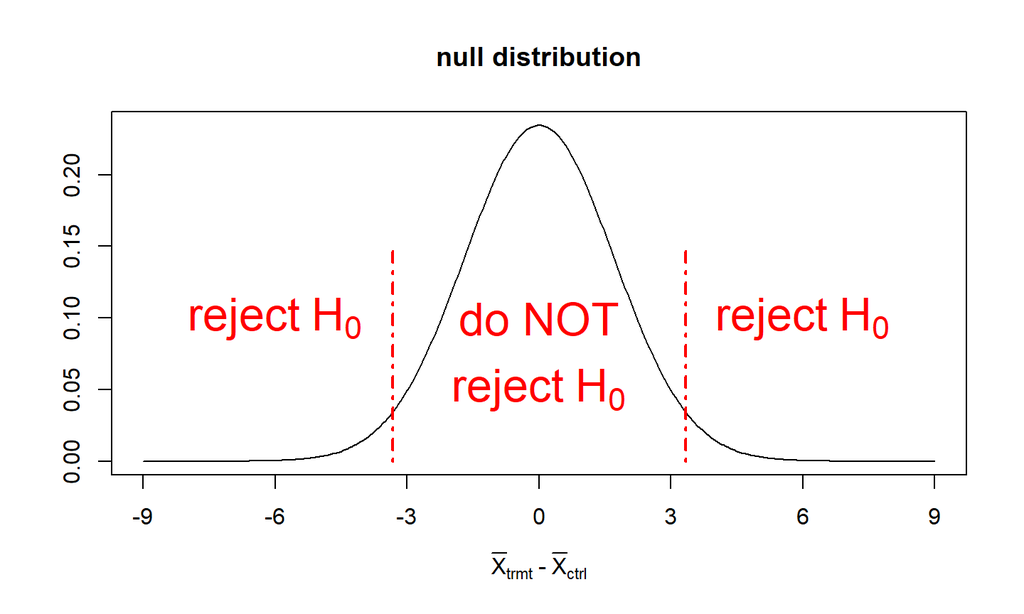

At this point if \(\overline{X_1} - \overline{X_2} = -3\) this effect would not be detected by the study at \(\alpha = 0.05\) level, when \(n_1 = n_2 = 100\)

If there is a true effect, the *probability* that we detect it given the *effect size*, our current sample size and significance level is called the **power** of the test. Supposing the **effect size** is 3mmHg, and the effect **is true** e.g. it shifts the null distribution

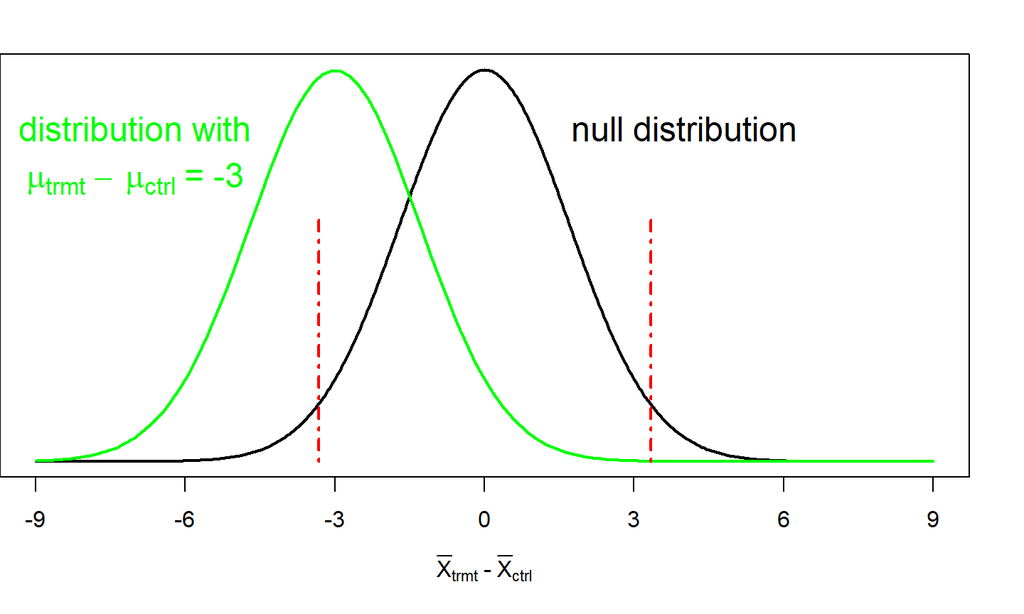

approximating the \(t\) distribution as normal, the probability is the area to the left of -3.33 under the **green** curve given by

\(\frac{-3.33 -(-3)}{1.70} = -0.20 \to 0.42\) is the power = 1-\(\beta\)

we ignore the upper rejection region in the calculation, since in this case you would reject \(H_0\) but make the wrong (opposite) conclusion!!

we found that if we have a sample size of 100 in each group, we can only detect an effect size of 3 mmHg with probability of 0.42

**This could be a big problem if researchers believe there is a real effect and we just didn't get big enough sample sizes to verify it**.

Millions are spent developing pharmaceuticals

\(\beta\) is the prob of type II error: not rejecting when \(H_0\) is false

- The most common practice is to identify the sample size where the power is around 80% or 90%. The method is
- given an effect size = 3, and desired power of 80%
  - calculate the Z-score `qnorm(0.8) =` 0.84
  - the rejection region extends \(1.96 \times SE\) from the center of the null distribution for \(\alpha = 0.05\) to form an interval \[0.84 \times SE + 1.96 \times SE = 2.8 \times SE = 3\] \[3 = 2.8 \sqrt{\frac{12^2}{n}+\frac{12^2}{n}}\] \[n \approx 250\]

## `power.test()` in R

```r
library(stats)
power.t.test(n=100,delta = -3,sd=12,sig.level=0.05,type="two.sample")
```

```
##
##      Two-sample t test power calculation
##
##               n = 100
##           delta = 3
##              sd = 12
##       sig.level = 0.05
##           power = 0.4204383
##     alternative = two.sided
##
## NOTE: n is number in *each* group
```

```r
power.t.test(n=253,delta = -3,sd=12,sig.level=0.05,type="two.sample")
```

```
##
##      Two-sample t test power calculation
##
##               n = 253
##           delta = 3
##              sd = 12
##       sig.level = 0.05
##           power = 0.8013574
##     alternative = two.sided
##
## NOTE: n is number in *each* group
```

Exactly one of the parameters n, delta, power, sd, and sig.level must be passed as NULL that parameter is determined from the others. NULL must be explicitly passed for some.

Notice that if the effect size (delta) is made bigger then the power is greater, if everything else is held fixed

```r
power.t.test(n=253,delta = -4,sd=12,sig.level=0.05,type="two.sample")
```

```
##
##      Two-sample t test power calculation
##
##               n = 253
##           delta = 4
##              sd = 12
##       sig.level = 0.05
##           power = 0.9626218
##     alternative = two.sided
##
## NOTE: n is number in *each* group
```

Notice that if the effect size (delta) is made smaller then the power is smaller, if everything else is held fixed

```r
power.t.test(n=253,delta = -2,sd=12,sig.level=0.05,type="two.sample")
```

```
##
##      Two-sample t test power calculation
##
##               n = 253
##           delta = 2
##              sd = 12
##       sig.level = 0.05
##           power = 0.4645412
##     alternative = two.sided
##
## NOTE: n is number in *each* group
```

The smaller the effect size (delta), the bigger you need \(n\) to be!!

## ANOVA

ANOVA is a method used when you have more than two groups and you want to compare the means to see if there any differences, you are doing *multiple comparisons*. It's like a more general version of the t-test.

**One-way ANOVA** has one continuous response variable (e.g. Test Score) compared by three or more levels of a **single factor variable** (e.g. Level of Education). Two way anova looks at responses to levels of two factor variables.

**Question: Is there a significant association between race and birthweight?**

\(H_0: \mu_1 = \mu_2 = ... = \mu_k\)

\(H_A\): At least one mean is different.

## Conditions for ANOVA

Generally we must check three conditions on the data before performing ANOVA: * the observations are independent within and across groups, * the data within each group are nearly normal, and * the variability across the groups is about equal.

If these conditions hold you calculate the variance of the group means about the grand mean called the mean squared between groups -\(MSG\). You also need a pooled estimate of the variance **within** the groups called mean square error-\(MSE\). Then the ratio \(\frac{MSG}{MSE}\) is \(F\) distributed if the Null hypothesis is true. The \(F\) distribution has two parameters \(df_G = k-1\) and \(df_E = n-k\)

note the sum of squared errors shown is related to the \(MSE\) by \(SSE = df_E MSE\)

## `aov()` in R

```r
ddply(birthwt, ~ race, summarize,
      mean.bwt = mean(birthwt.grams),
      sd.bwt = sd(birthwt.grams) / sqrt(length(birthwt.grams)))
```

```
##    race mean.bwt    sd.bwt
## 1 black 2719.692 125.25621
## 2 other 2805.284  88.23008
## 3 white 3102.719  74.28957
```

```r
summary(aov(birthwt.grams ~ race, data = birthwt)) # run anova
```

```
##              Df   Sum Sq Mean Sq F value  Pr(>F)
## race          2  5015725 2507863   4.913 0.00834 **
## Residuals   186 94953931  510505
## ---
## Signif. codes:  0 '***' 0.001 '**' 0.01 '*' 0.05 '.' 0.1 ' ' 1
```

## Mann Whitney U (Wilcoxon rank-sum)

The **U statistic** corresponds to the number of wins out of all pairwise contests between two groups.

- For each observation in one set, count the number of times this first value wins over any observations in the other set (the other value loses if this first is larger).
- Count 0.5 for any ties.
- The sum of wins and ties is U for the first set.
- U for the other set is the converse.

The distribution of \(U\) under the null hypothesis, is known.

The null hypothesis for the \(t\) test is that the two groups have the same population mean, for the wilcox test its different

- The null hypothesis of the Wilcoxon test is usually taken as equal medians.
- Another way to think of the null is that the two populations have the same distribution with the same median.
- If we reject the null, that means we have evidence that one distribution is shifted to the left or right of the other.
- Since we're assuming our distributions are equal, rejecting the null means we have evidence that the medians of the two populations differ.
- The R statistical programming environment, which we use to implement the Wilcoxon rank sum test below, refers to this a "location shift".
- Because wilcox test makes no assumptions such as normality about the distributions, it is called a *parameter free* test

```r
 wilcox.test(birthwt.grams ~ mother.smokes, data=birthwt, conf.int=T)
```

```
##
##  Wilcoxon rank sum test with continuity correction
##
## data:  birthwt.grams by mother.smokes
## W = 5249.5, p-value = 0.006768
## alternative hypothesis: true location shift is not equal to 0
## 95 percent confidence interval:
##   85.00004 512.00005
## sample estimates:
## difference in location
##               306.1846
```

The `~` in the expression `birthwt.grams ~ mother.smokes` in R, stands for *modelled as*

`birthwt.grams` is being modelled as a response variable to the factor variable `mother.smokes`

## Lab Unit 7

### Exercise #1

You should be aware of the condition that expected cell counts must be > 5

What are the expected cell counts in the example below?

Remember running chisq.test(x,p) without p assumes a discrete uniform distribution for the bin population proportions (the p vector is all equal). Run the code below in the console

```r
a <- table(sample(1:4,size=16,replace=T))
a
chisq.test(a)
```

Did you get a warning message?

### Exercise #2

There is an issue with running `chisq.test` on a table with margins.

Run the following code

```r
a <- addmargins(table(sample(1:4,size=30,replace=T)))
a
chisq.test(a)
```

**it will treat the margin like a bin** checkout that p-value!

Do you understand why the p-value is so small?

### exercise 3

Use fisher.test to see if there is an association in the table below

```r
smoking <- as.table(rbind(c(688,650),c(21,59)))
dimnames(smoking) <- list(has.smoked=c("yes","no"),lung.cancer=c("yes","no"))
smoking
```

```
##           lung.cancer
## has.smoked yes  no
##        yes 688 650
##        no   21  59
```

### Exercise 4: statistical power

A company that manufactures light bulbs claims that a particular type of light bulb will last 850 hours on average with standard deviation of 50. A consumer protection group thinks that the manufacturer has overestimated the lifespan of their light bulbs by about 40 hours. How many light bulbs does the consumer protection group have to test in order to prove their point with reasonable confidence?

Hint: use `type="one.sided"` in your power test!

### Exercise 5

It has been estimated that the average height of American white male adults is 70 inches. It has also been postulated that there is a positive correlation between height and intelligence. If this is true, then the average height of a white male graduate students on campus should be greater than the average height of American white male adults in general. You want to test this theory out by random sampling a small group of white male graduate students. But you need to know how small the group can be or how few people that you need to measure such that you can still prove your point.